# Analyzing Trends in Video Games on Steam

by Sean Ha

# Introduction

The video games industry is larger than it has ever been, with a global market value of over \$100 billion. In 2021, it is expected to reach approximately \$140 billion. There are various devices through which these games are distributed, including computers, game consoles, and smartphones. For each of these devices, there usually exist various storefronts through which games are sold. Examples of this include the Apple App Store for Apple devices, the Google Play Store for Android devices, the PlayStation Store for PlayStation consoles, and Steam for PCs. While there exist many other storefronts for PCs, we will be focusing our analysis on Steam, as it is currently the largest PC digital distributor for games.

Developing video games takes lots of time and money. If we could analyze data of existing games, we could perhaps reach conclusions about what types of games would be the most successful, or profitable, and minimize the chances of developing a game that will not sell particularly well. If you were a game designer or a manager at a game studio, you very well might be interested in this sort of data and analysis.

In recent times, through technological advancements and the rise of the internet, the barrier of entry for making a game has been drastically lowered. As a result, there has been a surge of "indie" game developers (usually classified by a small development team, that does not have the financial support of a large game publisher). These indie game developers are usually short on cash, and are relying on the success of their project to stay afloat. This type of data might be very useful to these "indies," as it could help them make an informed decision about what type of game to develop, and specific factors to think about that might maximize the chances of a successful game.

# Setup

Below are the libraries that we will be needing for this project. These will help us store, visualize, and analyze our data.

```python
import pandas as pd
import numpy as np
from datetime import datetime
import re
import seaborn as sns
import matplotlib.pyplot as plt
from scipy.stats import spearmanr
import statsmodels.api as sm
```

# Loading the Data

We are using a downloaded CSV file that contains the dataset. The dataset and a description of what it contains can be found here: https://data.world/craigkelly/steam-game-data. Please take a look at that page to understand what particular columns in the dataset might represent, and where the data came from. Feel free to download and explore the dataset, if you are interested.

We will load the dataset into a Pandas DataFrame. A DataFrame is a 2 dimensional data structure, similar to something like an SQL table. It will help us in organizing and analyzing our data, and makes it easy to work with.

```python
df = pd.read_csv("games-features.csv")
df.head()
```

|  | QueryID | ResponseID | QueryName | ResponseName | ReleaseDate | RequiredAge | DemoCount | DeveloperCount | DLCCount | Metacritic | ... | LegalNotice | Reviews | SupportedLanguages | Website | PCMinReqsText | PCRecReqsText | LinuxMinReqsText | LinuxRecReqsText | MacMinReqsText | MacRecReqsText |
| --- | --- | --- | --- | --- | --- | --- | --- | --- | --- | --- | --- | --- | --- | --- | --- | --- | --- | --- | --- | --- | --- |
| 0 | 10 | 10 | Counter-Strike | Counter-Strike | Nov 1 2000 | 0 | 0 | 1 | 0 | 88 | ... |  |  | English French German Italian Spanish Simplifi... | None | Minimum: 500 mhz processor 96mb ram 16mb video... |  | Minimum: Linux Ubuntu 12.04 Dual-core from Int... |  | Minimum: OS X Snow Leopard 10.6.3 1GB RAM 4GB... |  |
| 1 | 20 | 20 | Team Fortress Classic | Team Fortress Classic | Apr 1 1999 | 0 | 0 | 1 | 0 | 0 | ... |  |  | English French German Italian Spanish | None | Minimum: 500 mhz processor 96mb ram 16mb video... |  | Minimum: Linux Ubuntu 12.04 Dual-core from Int... |  | Minimum: OS X Snow Leopard 10.6.3 1GB RAM 4GB... |  |
| 2 | 30 | 30 | Day of Defeat | Day of Defeat | May 1 2003 | 0 | 0 | 1 | 0 | 79 | ... |  |  | English French German Italian Spanish | http://www.dayofdefeat.com/ | Minimum: 500 mhz processor 96mb ram 16mb video... |  | Minimum: Linux Ubuntu 12.04 Dual-core from Int... |  | Minimum: OS X Snow Leopard 10.6.3 1GB RAM 4GB... |  |
| 3 | 40 | 40 | Deathmatch Classic | Deathmatch Classic | Jun 1 2001 | 0 | 0 | 1 | 0 | 0 | ... |  |  | English French German Italian Spanish | None | Minimum: 500 mhz processor 96mb ram 16mb video... |  | Minimum: Linux Ubuntu 12.04 Dual-core from Int... |  | Minimum: OS X Snow Leopard 10.6.3 1GB RAM 4GB... |  |
| 4 | 50 | 50 | Half-Life: Opposing Force | Half-Life: Opposing Force | Nov 1 1999 | 0 | 0 | 1 | 0 | 0 | ... |  |  | English French German Korean | None | Minimum: 500 mhz processor 96mb ram 16mb video... |  | Minimum: Linux Ubuntu 12.04 Dual-core from Int... |  | Minimum: OS X Snow Leopard 10.6.3 1GB RAM 4GB... |  |

5 rows × 78 columns

We will also load a second, somewhat related dataset that contains information regarding playtime and purchases of games by users on Steam. The dataset can be found here: https://www.kaggle.com/tamber/steam-video-games.

Once again, this dataset has been downloaded, and will be loaded into a Pandas DataFrame. Feel free to check it out yourself, and see what sort of data it contains.

```python
play_df = pd.read_csv("steam-pp-data.csv", header=None, names=['UserID', 'GameName', 'Type', 'Hours', '0'])

# Drop pointless columns of User ID's and all 0's
play_df = play_df.drop(['UserID', '0'], axis=1)

play_df.head()
```

|  | GameName | Type | Hours |
| --- | --- | --- | --- |
| 0 | The Elder Scrolls V Skyrim | purchase | 1.0 |
| 1 | The Elder Scrolls V Skyrim | play | 273.0 |
| 2 | Fallout 4 | purchase | 1.0 |
| 3 | Fallout 4 | play | 87.0 |
| 4 | Spore | purchase | 1.0 |

# Tidy Data

This dataset contains a ton of columns. We will drop the unnecessary ones that we will not need in this project. For us, that includes the following:

- SteamSpyOwnersVariance
- SteamSpyPlayersVariance
- PurchaseAvail
- SubscriptionAvail
- PlatformWindows
- PlatformMac
- PlatformLinux
- PCReqsHaveMin
- PCReqsHaveRec
- LinuxReqsHaveMin
- LinuxReqsHaveRec
- MacReqsHaveMin
- MacReqsHaveRec
- DemoCount
- DeveloperCount
- DLCCount
- MovieCount
- PackageCount
- PublisherCount
- AchievementHighlightedCount
- PriceCurrency
- PriceFinal
- SupportEmail
- SupportURL
- AboutText
- Background
- ShortDescrip
- DetailedDescrip
- DRMNotice
- ExtUserAcctNotice
- HeaderImage
- LegalNotice
- Reviews
- Website
- PCMinReqsText
- PCRecReqsText
- LinuxMinReqsText
- LinuxRecReqsText
- MacMinReqsText
- MacRecReqsText

We will remove these columns in particular because they generally contain information that is either meaningless to analyze, or simply not relevant to this project.

```python
# Drop the columns specified above
df = df.drop(['SteamSpyOwnersVariance', 'SteamSpyPlayersVariance', 'PurchaseAvail', 'SubscriptionAvail',
              'PlatformWindows', 'PlatformMac', 'PlatformLinux', 'PCReqsHaveMin', 'PCReqsHaveRec', 'LinuxReqsHaveMin',
              'LinuxReqsHaveRec', 'MacReqsHaveMin', 'MacReqsHaveRec', 'DemoCount', 'DeveloperCount', 'DLCCount',
              'MovieCount', 'PackageCount', 'PublisherCount', 'AchievementHighlightedCount', 'PriceCurrency',
              'PriceFinal', 'SupportEmail', 'SupportURL', 'AboutText', 'Background', 'ShortDescrip',
              'DetailedDescrip', 'DRMNotice','ExtUserAcctNotice', 'HeaderImage', 'LegalNotice', 'Reviews', 'Website',
              'PCMinReqsText', 'PCRecReqsText', 'LinuxMinReqsText', 'LinuxRecReqsText', 'MacMinReqsText',
              'MacRecReqsText'], axis=1)
df.head()
```

|  | QueryID | ResponseID | QueryName | ResponseName | ReleaseDate | RequiredAge | Metacritic | RecommendationCount | ScreenshotCount | SteamSpyOwners | ... | GenreIsStrategy | GenreIsRPG | GenreIsSimulation | GenreIsEarlyAccess | GenreIsFreeToPlay | GenreIsSports | GenreIsRacing | GenreIsMassivelyMultiplayer | PriceInitial | SupportedLanguages |
| --- | --- | --- | --- | --- | --- | --- | --- | --- | --- | --- | --- | --- | --- | --- | --- | --- | --- | --- | --- | --- | --- |
| 0 | 10 | 10 | Counter-Strike | Counter-Strike | Nov 1 2000 | 0 | 88 | 68991 | 13 | 13033334 | ... | False | False | False | False | False | False | False | False | 9.99 | English French German Italian Spanish Simplifi... |
| 1 | 20 | 20 | Team Fortress Classic | Team Fortress Classic | Apr 1 1999 | 0 | 0 | 2439 | 5 | 5399140 | ... | False | False | False | False | False | False | False | False | 4.99 | English French German Italian Spanish |
| 2 | 30 | 30 | Day of Defeat | Day of Defeat | May 1 2003 | 0 | 79 | 2319 | 5 | 7621102 | ... | False | False | False | False | False | False | False | False | 4.99 | English French German Italian Spanish |
| 3 | 40 | 40 | Deathmatch Classic | Deathmatch Classic | Jun 1 2001 | 0 | 0 | 888 | 4 | 7498965 | ... | False | False | False | False | False | False | False | False | 4.99 | English French German Italian Spanish |
| 4 | 50 | 50 | Half-Life: Opposing Force | Half-Life: Opposing Force | Nov 1 1999 | 0 | 0 | 2934 | 5 | 5399499 | ... | False | False | False | False | False | False | False | False | 4.99 | English French German Korean |

5 rows × 38 columns

Let's rename one of the columns so that it is more clear what the column is describing.

```python
df = df.rename(columns={'PriceInitial': 'Price'})
```

Now let's clean up the "SupportedLanguages" column. Currently, some observations contain unnecessary information in that column. What we what to extract is the number of languages that a particular game supports. In addition, we will want to take a look at some major languages, and see what impact they might have on the success of a game. We could hypothetically perform this on every single language, but since there are so many, we will limit our analysis to a few major ones. If you are interested in a particular language that I do not include, feel free to try it out yourself and see what kind of results you get!

What we will do is split the data in "SupportedLanguages" up into a few new columns. One for the number of languages the game supports ("LangSupportedCount"). And then additional columns for whether or not a particular game supports a particular language (e.g. a column named "SupportsEnglish" would contain 1 if the game support English, and 0 if it does not).

The "SupportedLanguages" column contains a bunch of data mashed together. This will separate the different parts of the data from one column into multiple columns, making it easier for analysis in the future. We want multiple columns to contain specialized information, as opposed to having one column with very general information.

For this project, here are the languages that we will create specific columns for:

- English
- French
- Spanish
- Japanese
- Chinese (1 if game supports traditional, simplified, or both; 0 if neither)
- Korean

```python
# Create column for number of languages supported
df['LangSupportCount'] = 0

# Create columns for the specific languages specified above
df['SupportsEnglish'] = 0
df['SupportsFrench'] = 0
df['SupportsSpanish'] = 0
df['SupportsJapanese'] = 0
df['SupportsChinese'] = 0
df['SupportsKorean'] = 0

for index, row in df.iterrows():
    # Remove unnecessary data (asterisks, the string "languages with full audio support")
    langs = df.iloc[index].SupportedLanguages
    df.loc[index, 'SupportedLanguages'] = langs.replace('*', '')
    langs = df.iloc[index].SupportedLanguages
    df.loc[index, 'SupportedLanguages'] = langs.replace('languages with full audio support', '')

    # Get list of all languages supported
    lang_list = df.iloc[index].SupportedLanguages.split()
    # Converts languages to all uppercase for case insensitivity
    lang_list = [lang.upper() for lang in lang_list]

    # Removes unnecessary additional arguments
    if 'TRADITIONAL' in lang_list:
        lang_list.remove('TRADITIONAL')
    if 'SIMPLIFIED' in lang_list:
        lang_list.remove('SIMPLIFIED')

    # Get number of languages supported.
    # Note we count Traditional Chinese and Simplified Chinese as two different languages for this purpose.
    df.loc[index, 'LangSupportCount'] = len(lang_list)


    # Put values for whether or not game supports each language
    if 'ENGLISH' in lang_list:
        df.loc[index, 'SupportsEnglish'] = 1
    if 'FRENCH' in lang_list:
        df.loc[index, 'SupportsFrench'] = 1
    if 'SPANISH' in lang_list:
        df.loc[index, 'SupportsSpanish'] = 1
    if 'JAPANESE' in lang_list:
        df.loc[index, 'SupportsJapanese'] = 1
    # Accounts for both Traditional and Simplified Chinese
    if 'CHINESE' in lang_list:
        df.loc[index, 'SupportsChinese'] = 1
    if 'KOREAN' in lang_list:
        df.loc[index, 'SupportsKorean'] = 1

# Drop the now unnecessary "SupportedLanguages" column
df = df.drop(['SupportedLanguages'], axis=1)
```

Next, we will convert the boolean columns into integer columns. So in other words, True becomes 1, and False becomes 0. This will allow us to perform operations on these columns that can only be done on numerical values.

```python
# Converts true into 1, false into 0
for col in df.columns:
    if df[col].dtype == bool:
        df[col] = df[col].astype(int)
df.head()
```

|  | QueryID | ResponseID | QueryName | ResponseName | ReleaseDate | RequiredAge | Metacritic | RecommendationCount | ScreenshotCount | SteamSpyOwners | ... | GenreIsRacing | GenreIsMassivelyMultiplayer | Price | LangSupportCount | SupportsEnglish | SupportsFrench | SupportsSpanish | SupportsJapanese | SupportsChinese | SupportsKorean |
| --- | --- | --- | --- | --- | --- | --- | --- | --- | --- | --- | --- | --- | --- | --- | --- | --- | --- | --- | --- | --- | --- |
| 0 | 10 | 10 | Counter-Strike | Counter-Strike | Nov 1 2000 | 0 | 88 | 68991 | 13 | 13033334 | ... | 0 | 0 | 9.99 | 8 | 1 | 1 | 1 | 0 | 1 | 1 |
| 1 | 20 | 20 | Team Fortress Classic | Team Fortress Classic | Apr 1 1999 | 0 | 0 | 2439 | 5 | 5399140 | ... | 0 | 0 | 4.99 | 5 | 1 | 1 | 1 | 0 | 0 | 0 |
| 2 | 30 | 30 | Day of Defeat | Day of Defeat | May 1 2003 | 0 | 79 | 2319 | 5 | 7621102 | ... | 0 | 0 | 4.99 | 5 | 1 | 1 | 1 | 0 | 0 | 0 |
| 3 | 40 | 40 | Deathmatch Classic | Deathmatch Classic | Jun 1 2001 | 0 | 0 | 888 | 4 | 7498965 | ... | 0 | 0 | 4.99 | 5 | 1 | 1 | 1 | 0 | 0 | 0 |
| 4 | 50 | 50 | Half-Life: Opposing Force | Half-Life: Opposing Force | Nov 1 1999 | 0 | 0 | 2934 | 5 | 5399499 | ... | 0 | 0 | 4.99 | 4 | 1 | 1 | 0 | 0 | 0 | 1 |

5 rows × 44 columns

It turns out that certain columns and rows may have data that is not good to work with. In particular, the table contains observations for not only the games themselves, but also for their DLCs (additional downloadable content), and any other possible store results. We want to remove these observations, as they are essentially causing repeat rows.

In addition, there appear to be repeated observations without any identifiable cause. One example is the following:

```python
# Find all observations with a ResponseName of 'Portal 2'
df[df['ResponseName'] == 'Portal 2']
```

|  | QueryID | ResponseID | QueryName | ResponseName | ReleaseDate | RequiredAge | Metacritic | RecommendationCount | ScreenshotCount | SteamSpyOwners | ... | GenreIsRacing | GenreIsMassivelyMultiplayer | Price | LangSupportCount | SupportsEnglish | SupportsFrench | SupportsSpanish | SupportsJapanese | SupportsChinese | SupportsKorean |
| --- | --- | --- | --- | --- | --- | --- | --- | --- | --- | --- | --- | --- | --- | --- | --- | --- | --- | --- | --- | --- | --- |
| 24 | 620 | 620 | Portal 2 | Portal 2 | Apr 18 2011 | 0 | 95 | 73128 | 12 | 8741499 | ... | 0 | 0 | 19.99 | 22 | 1 | 1 | 1 | 1 | 1 | 1 |
| 26 | 620 | 620 | Portal 2 | Portal 2 | Apr 18 2011 | 0 | 95 | 73128 | 12 | 8741499 | ... | 0 | 0 | 19.99 | 22 | 1 | 1 | 1 | 1 | 1 | 1 |
| 928 | 659 | 620 | Portal 2 - Pre-order | Portal 2 | Apr 18 2011 | 0 | 95 | 73144 | 12 | 0 | ... | 0 | 0 | 19.99 | 22 | 1 | 1 | 1 | 1 | 1 | 1 |

3 rows × 44 columns

Here we can see that the game 'Portal 2' is listed 3 times, which all refer to the same game. Next, I will show how I will remove these observations from the table for this particular dataset.

The QueryID corresponds to the QueryName, and the ResponseID corresponds to the ResponseName. In theory, QueryID should always equal ResponseID and QueryName should always equal ResponseName. However, this is not always the case, as we can see in the above example. This can clearly cause issues when operating on this data, as one game can appear multiple times.

We know a row must have an invalid observation if it turns out that the QueryID does not equal the ResponseID (invalid meaning that the Query and Response are not exactly the same). In addition, each QueryID should only appear once throughout the entire table. Similarly, each ResponseID should only appear once as well. Then, we can remove any repeated rows defined by these conditions. We will consider the first instance of each QueryID and ResponseID to be the valid observation, with any future duplicates being considered "invalid" observations, which are removed. This is fine, because as mentioned earlier, we are only removing duplicate rows that will otherwise skew our data.

```python
# Removes all entries where QueryID != ResponseID
df = df[df['QueryID'] == df['ResponseID']]
# Removes entries with duplicate QueryID or ResponseID's
df = df.drop_duplicates(subset='QueryID')
df = df.drop_duplicates(subset='ResponseID')
```

Now we will remove the unnecessary columns that we no longer need. The columns to be removed are listed below:

- QueryID
- ResponseID
- QueryName

Then we will also rename ResponseName to GameName to better describe the data it contains.

```python
df = df.drop(['QueryID', 'ResponseID', 'QueryName'], axis=1)
df = df.rename(columns={'ResponseName': 'GameName'})
df.head()
```

|  | GameName | ReleaseDate | RequiredAge | Metacritic | RecommendationCount | ScreenshotCount | SteamSpyOwners | SteamSpyPlayersEstimate | AchievementCount | ControllerSupport | ... | GenreIsRacing | GenreIsMassivelyMultiplayer | Price | LangSupportCount | SupportsEnglish | SupportsFrench | SupportsSpanish | SupportsJapanese | SupportsChinese | SupportsKorean |
| --- | --- | --- | --- | --- | --- | --- | --- | --- | --- | --- | --- | --- | --- | --- | --- | --- | --- | --- | --- | --- | --- |
| 0 | Counter-Strike | Nov 1 2000 | 0 | 88 | 68991 | 13 | 13033334 | 9140731 | 0 | 0 | ... | 0 | 0 | 9.99 | 8 | 1 | 1 | 1 | 0 | 1 | 1 |
| 1 | Team Fortress Classic | Apr 1 1999 | 0 | 0 | 2439 | 5 | 5399140 | 753627 | 0 | 0 | ... | 0 | 0 | 4.99 | 5 | 1 | 1 | 1 | 0 | 0 | 0 |
| 2 | Day of Defeat | May 1 2003 | 0 | 79 | 2319 | 5 | 7621102 | 1709740 | 0 | 0 | ... | 0 | 0 | 4.99 | 5 | 1 | 1 | 1 | 0 | 0 | 0 |
| 3 | Deathmatch Classic | Jun 1 2001 | 0 | 0 | 888 | 4 | 7498965 | 789676 | 0 | 0 | ... | 0 | 0 | 4.99 | 5 | 1 | 1 | 1 | 0 | 0 | 0 |
| 4 | Half-Life: Opposing Force | Nov 1 1999 | 0 | 0 | 2934 | 5 | 5399499 | 705741 | 0 | 0 | ... | 0 | 0 | 4.99 | 4 | 1 | 1 | 0 | 0 | 0 | 1 |

5 rows × 41 columns

We will now move on to correctly parsing and formatting the ReleaseDate column.

One thing to note is that the ReleaseDate column has no clear format. In fact, it appears as if any sort of string can appear in this column. If we just take a look at the first few rows, it appears as though there is a clear format. However, there are many observations that do not follow this format even slightly, making it very difficult to work with. For example, some values include 'Nov 1 2000', which is the standard format, but other values can include: 'Feb 2011', 'Coming Soon', 'TBA', 'Fall 2016', and even some extraordinary ones like 'The League of Evil is preparing its evil plans...'. Therefore, it is very difficult to get this data into a standardized form, with such variation in data.

My solution is to scan each ReleaseDate string for a year value (any 4 digit number starting with 19 or 20). Then we will create a new column called 'ReleaseYear' that will contain this value. We will ignore the month and day, even if it happens to be in the ReleaseDate. Any rows that do not have a year value with become NaN. This is a relatively easy solution to implement that is able to extract the meaningful data from the ReleaseDate column, even with all of the variation. In addition, the year value is arguably the most important part of the ReleaseDate, and it is a number that most ReleaseDate strings include, even if they do not include a month or day.

We will use regular expressions to locate the year.

```python
df['ReleaseYear'] = np.nan

for index, row in df.iterrows():
    match = re.search("(19|20)\d\d", row.ReleaseDate)
    # No match is found
    if match is None:
        df.loc[index, 'ReleaseYear'] = np.nan
    # Match is found
    else:
        df.loc[index, 'ReleaseYear'] = int(match.group())
```

Looks good! We will remove the now unnecessary ReleaseDate column, and move the ReleaseYear column to be the 2nd column in the DataFrame. In addition, we will move the Price column to the third column, for readability.

```python
cols = df.columns.tolist()
cols = [cols[0]] + cols[-1:] + [cols[-9:][0]] + cols[1:-9] + cols[-8:-1]
df = df[cols]
df = df.drop(['ReleaseDate'], axis=1)
```

```python
df.head()
```

|  | GameName | ReleaseYear | Price | RequiredAge | Metacritic | RecommendationCount | ScreenshotCount | SteamSpyOwners | SteamSpyPlayersEstimate | AchievementCount | ... | GenreIsSports | GenreIsRacing | GenreIsMassivelyMultiplayer | LangSupportCount | SupportsEnglish | SupportsFrench | SupportsSpanish | SupportsJapanese | SupportsChinese | SupportsKorean |
| --- | --- | --- | --- | --- | --- | --- | --- | --- | --- | --- | --- | --- | --- | --- | --- | --- | --- | --- | --- | --- | --- |
| 0 | Counter-Strike | 2000.0 | 9.99 | 0 | 88 | 68991 | 13 | 13033334 | 9140731 | 0 | ... | 0 | 0 | 0 | 8 | 1 | 1 | 1 | 0 | 1 | 1 |
| 1 | Team Fortress Classic | 1999.0 | 4.99 | 0 | 0 | 2439 | 5 | 5399140 | 753627 | 0 | ... | 0 | 0 | 0 | 5 | 1 | 1 | 1 | 0 | 0 | 0 |
| 2 | Day of Defeat | 2003.0 | 4.99 | 0 | 79 | 2319 | 5 | 7621102 | 1709740 | 0 | ... | 0 | 0 | 0 | 5 | 1 | 1 | 1 | 0 | 0 | 0 |
| 3 | Deathmatch Classic | 2001.0 | 4.99 | 0 | 0 | 888 | 4 | 7498965 | 789676 | 0 | ... | 0 | 0 | 0 | 5 | 1 | 1 | 1 | 0 | 0 | 0 |
| 4 | Half-Life: Opposing Force | 1999.0 | 4.99 | 0 | 0 | 2934 | 5 | 5399499 | 705741 | 0 | ... | 0 | 0 | 0 | 4 | 1 | 1 | 0 | 0 | 0 | 1 |

5 rows × 41 columns

# Missing Data

In many instances, your data might contain missing values. You will have to decide how you want to handle such missing data. We will check this dataset to see if there are any missing values. The following code snippet will print the columns that contain any NaN values, and the number of NaN values in each of those columns

```python
# Find number of empty values in all columns
missing_count_df = pd.DataFrame(df.isna().sum(),columns=["Missing Values"])
missing_count_df[(missing_count_df.T != 0).any()]
```

|  | Missing Values |
| --- | --- |
| ReleaseYear | 248 |

Luckily in our case, we can see that we do not have any data that is missing, excluding the values that we purposefully set to NaN in ReleaseYear. If it turned out that we did happen to have some missing data, we would need to figure out a way to handle it. For example, we could just ignore those observations, or we could fill them in using other non-missing data from the dataset. It is up to you to figure out how you want to handle it, for your specific dataset.

The Metacritic column contains a value which is the "score" that Metacritic gives the game, on a scale from 0 to 100, with 100 being the best possible. An important note to make is that a value of 0 in the Metacritic column should be considered a missing value, as it means that Metacritic has not given a score to that game. Theoretically, it could also mean that the game was given a 0 score, but Metacritic has never given out a score of 0 to a game. As a result, we will convert all zeroes in the Metacritic column to NaN values, so that these missing values do not skew our data.

For a bit of background, Metacritic is a website that aggregates reviews from different sources and publications. It then weights the reviews, and averages them to create the Metacritic score. For more information about Metacrtitic and their scoring system, check out this page by Metacritic: https://www.metacritic.com/about-metascores

```python
# All zeroes in Metacritic column get turned into NaN
for index, row in df.iterrows():
    if row.Metacritic == 0:
        df.loc[index, 'Metacritic'] = np.nan
```

We have verified our 1st dataset has no missing values. Now let's check our 2nd dataset for any missing values.

```python
# Find number of empty values in all columns
missing_count_play_df = pd.DataFrame(play_df.isna().sum(),columns=["Missing Values"])
missing_count_play_df[(missing_count_play_df.T != 0).any()]
```

|  | Missing Values |
| --- | --- |

Great, there are no missing values in this dataset either!

Now we will merge the two datasets so that all the data is in one centralized DataFrame. First, we need to be able to match a row in one DataFrame with a row in another. We will do this by game name. To make sure subtle differences in game names are ignored, we will standardize each game name. We will do this by making all game names uppercase, removing any special characters they might contain, and removing all spaces between words. In addition, some names might contain the substring "(r)" or "(tm)" which also should be removed. Let's do it.

```python
# Changes all GameNames to uppercase in df
df['GameName'] = df['GameName'].str.upper()

pattern = re.compile('[\W_]+')

for index, row in df.iterrows():
    # Removes all (R) and (TM) in GameName
    df.loc[index, 'GameName'].replace('(r)', '')
    df.loc[index, 'GameName'].replace('(tm)', '')

    df.loc[index, 'GameName'] = pattern.sub('', row.GameName)
```

```python
# Standardizes GameNames for play_df
play_df['GameName'] = play_df['GameName'].str.upper()

pattern = re.compile('[\W_]+')

# Create dictionary for old name -> standardized name
d = {game_name: pattern.sub('', game_name) for game_name in play_df.GameName.unique()}

# Remove all non-alphanumeric characters
play_df['GameName'] = play_df['GameName'].replace(d)
```

Now the GameNames should be the same across both tables for any two games which are the same between the tables.

So now we will combine all the data from play_df into columns in df. To do this, we will calulate the total number of purchases for each game by summing up the total number of 'purchase' type rows in play_df. Then we will calculate the total playtime for each game by summing up the total hours for all 'play' type rows. We will also create a column which is total playtime / number of purchases to obtain the average number of hours played by a person who bought the game. This is to standardize the data, as then we can see which games have a high or low playtime per user (so the number of players a game has is taken into account).

```python
# Dictionary to contain key=GameName, value=total number of purchasers
purchase_dict = {}
# Dictionary to contain key=GameName, value=total number of hours played
playtime_dict = {}

for index, row in play_df.iterrows():
    if row.Type == 'purchase':
        curr = purchase_dict.setdefault(row.GameName, 0)
        purchase_dict[row.GameName] = curr + 1
    else:
        curr = playtime_dict.setdefault(row.GameName, 0)
        playtime_dict[row.GameName] = curr + row.Hours
```

```python
# Create new columns
df['TotalBuyers'] = 0
df['TotalPlaytime'] = 0

indices = df.index

# Add values to TotalBuyers col
for key in purchase_dict:
    # Get index of row corresponding to this GameName
    i = indices[df['GameName'] == key]
    # If the game is in the DataFrame
    if not i.empty:
        df.loc[i[0], 'TotalBuyers'] = purchase_dict[key]
```

```python
# Add values to TotalPlaytime col
for key in playtime_dict:
    # Get index of row corresponding to this GameName
    i = indices[df['GameName'] == key]
    # If the game is in the DataFrame
    if not i.empty:
        df.loc[i[0], 'TotalPlaytime'] = playtime_dict[key]
```

```python
df.head()
```

|  | GameName | ReleaseYear | Price | RequiredAge | Metacritic | RecommendationCount | ScreenshotCount | SteamSpyOwners | SteamSpyPlayersEstimate | AchievementCount | ... | GenreIsMassivelyMultiplayer | LangSupportCount | SupportsEnglish | SupportsFrench | SupportsSpanish | SupportsJapanese | SupportsChinese | SupportsKorean | TotalBuyers | TotalPlaytime |
| --- | --- | --- | --- | --- | --- | --- | --- | --- | --- | --- | --- | --- | --- | --- | --- | --- | --- | --- | --- | --- | --- |
| 0 | COUNTERSTRIKE | 2000.0 | 9.99 | 0 | 88.0 | 68991 | 13 | 13033334 | 9140731 | 0 | ... | 0 | 8 | 1 | 1 | 1 | 0 | 1 | 1 | 856 | 134261.1 |
| 1 | TEAMFORTRESSCLASSIC | 1999.0 | 4.99 | 0 | NaN | 2439 | 5 | 5399140 | 753627 | 0 | ... | 0 | 5 | 1 | 1 | 1 | 0 | 0 | 0 | 366 | 22.7 |
| 2 | DAYOFDEFEAT | 2003.0 | 4.99 | 0 | 79.0 | 2319 | 5 | 7621102 | 1709740 | 0 | ... | 0 | 5 | 1 | 1 | 1 | 0 | 0 | 0 | 534 | 1351.5 |
| 3 | DEATHMATCHCLASSIC | 2001.0 | 4.99 | 0 | NaN | 888 | 4 | 7498965 | 789676 | 0 | ... | 0 | 5 | 1 | 1 | 1 | 0 | 0 | 0 | 524 | 23.7 |
| 4 | HALFLIFEOPPOSINGFORCE | 1999.0 | 4.99 | 0 | NaN | 2934 | 5 | 5399499 | 705741 | 0 | ... | 0 | 4 | 1 | 1 | 0 | 0 | 0 | 1 | 366 | 171.4 |

5 rows × 43 columns

Now we have successfully merged the data from play_df into one DataFrame, df. Note that as the number of buyers increases, the playtime will naturally increase. We want to see the average playtime of a typical player, regardless of how popular a game is. We will find this by taking TotalPlaytime / TotalBuyers. We will create a new column to store this value for each row. Let's call this new column 'AveragePlaytime'.

```python
df['AveragePlaytime'] = df['TotalPlaytime'] / df['TotalBuyers']
df.head()
```

|  | GameName | ReleaseYear | Price | RequiredAge | Metacritic | RecommendationCount | ScreenshotCount | SteamSpyOwners | SteamSpyPlayersEstimate | AchievementCount | ... | LangSupportCount | SupportsEnglish | SupportsFrench | SupportsSpanish | SupportsJapanese | SupportsChinese | SupportsKorean | TotalBuyers | TotalPlaytime | AveragePlaytime |
| --- | --- | --- | --- | --- | --- | --- | --- | --- | --- | --- | --- | --- | --- | --- | --- | --- | --- | --- | --- | --- | --- |
| 0 | COUNTERSTRIKE | 2000.0 | 9.99 | 0 | 88.0 | 68991 | 13 | 13033334 | 9140731 | 0 | ... | 8 | 1 | 1 | 1 | 0 | 1 | 1 | 856 | 134261.1 | 156.847079 |
| 1 | TEAMFORTRESSCLASSIC | 1999.0 | 4.99 | 0 | NaN | 2439 | 5 | 5399140 | 753627 | 0 | ... | 5 | 1 | 1 | 1 | 0 | 0 | 0 | 366 | 22.7 | 0.062022 |
| 2 | DAYOFDEFEAT | 2003.0 | 4.99 | 0 | 79.0 | 2319 | 5 | 7621102 | 1709740 | 0 | ... | 5 | 1 | 1 | 1 | 0 | 0 | 0 | 534 | 1351.5 | 2.530899 |
| 3 | DEATHMATCHCLASSIC | 2001.0 | 4.99 | 0 | NaN | 888 | 4 | 7498965 | 789676 | 0 | ... | 5 | 1 | 1 | 1 | 0 | 0 | 0 | 524 | 23.7 | 0.045229 |
| 4 | HALFLIFEOPPOSINGFORCE | 1999.0 | 4.99 | 0 | NaN | 2934 | 5 | 5399499 | 705741 | 0 | ... | 4 | 1 | 1 | 0 | 0 | 0 | 1 | 366 | 171.4 | 0.468306 |

5 rows × 44 columns

Note that this operation makes AveragePlaytime NaN if the value of the denominator 'TotalBuyers' equals zero. This is actually what we want, as this means we are missing data for that particular game.

With this, we have finished tidying our data. We can move on to the next step.

# EDA

EDA, or Exploratory Data Analysis is the process of displaying the data in different forms to analyze trends and form hypotheses.

We will create a correlation matrix to get a general overview of how our data might be correlated. A correlation matrix displays the correlation coefficients of pairs of variables in the data. Since we have a lot of columns, I will take a subset of this data to create a correlation matrix. We will only perform this operation on the variables that I think are interesting to look at. This is, of course, subjective, and if you have particular variables that you care about, feel free to try them out yourself!

We will calculate the Pearson correlation coefficient, since these variables that we will analyze are all continuous. If it turned out that you wanted to find the correlation of non-continuous, or qualitative variables, then you might want to take a look at computing the Spearman correlation coefficient.

```python
# Columns to calculate correlation coefficient of
corr_cols = ['ReleaseYear', 'Price', 'Metacritic', 'RecommendationCount', 'ScreenshotCount', 'SteamSpyOwners',
             'SteamSpyPlayersEstimate', 'AchievementCount', 'LangSupportCount', 'TotalBuyers', 'AveragePlaytime']
corr_df = df[corr_cols]
```

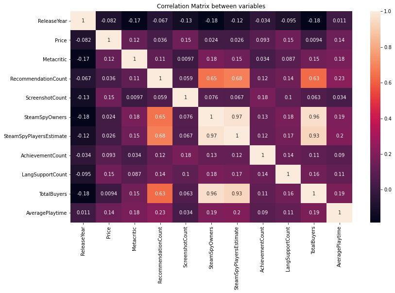

```python
# Create correlation matrix
corr_matrix = corr_df.corr()

plt.subplots(figsize = (13,8))
hm = sns.heatmap(corr_matrix, annot=True)
hm.set_title('Correlation Matrix between variables')
plt.show()
```

Looking at this correlation matrix, there do not seem to be any outstanding results. It is generally what we would expect. The RecommendationCount naturally increases as the number of player (SteamSpyPlayersEstimate) increases. And of course TotalBuyers and SteamSpyOwners are heavily correlated as well, since they are essentially measuring the same thing (number of owners of a game).

However, this does raise a good point to consider. We care more about the percentage of the playerbase that recommends a game as opposed to the total number of recommendations. This is because very popular games are heavily skewed by having a large number of recommendations, since they have tons of players. Let's make this change. In addition, since TotalBuyers and SteamSpyOwners are essentially measuring the same thing, we will remove the TotalBuyers column and use the SteamSpyOwners column to represent the number of owners of each game.

```python
# Remove TotalBuyers column
df = df.drop(['TotalBuyers'], axis=1)
;
```

```
''
```

```python
# Create new column 'StandardizedRec'
df['StandardizedRec'] = df['RecommendationCount'] / df['SteamSpyPlayersEstimate']
# Convert inf to NaN (inf might be caused by dividing by zero)
df.loc[~np.isfinite(df['StandardizedRec']), 'StandardizedRec'] = np.nan
```

```python
df.head()
```

|  | GameName | ReleaseYear | Price | RequiredAge | Metacritic | RecommendationCount | ScreenshotCount | SteamSpyOwners | SteamSpyPlayersEstimate | AchievementCount | ... | LangSupportCount | SupportsEnglish | SupportsFrench | SupportsSpanish | SupportsJapanese | SupportsChinese | SupportsKorean | TotalPlaytime | AveragePlaytime | StandardizedRec |
| --- | --- | --- | --- | --- | --- | --- | --- | --- | --- | --- | --- | --- | --- | --- | --- | --- | --- | --- | --- | --- | --- |
| 0 | COUNTERSTRIKE | 2000.0 | 9.99 | 0 | 88.0 | 68991 | 13 | 13033334 | 9140731 | 0 | ... | 8 | 1 | 1 | 1 | 0 | 1 | 1 | 134261.1 | 156.847079 | 0.007548 |
| 1 | TEAMFORTRESSCLASSIC | 1999.0 | 4.99 | 0 | NaN | 2439 | 5 | 5399140 | 753627 | 0 | ... | 5 | 1 | 1 | 1 | 0 | 0 | 0 | 22.7 | 0.062022 | 0.003236 |
| 2 | DAYOFDEFEAT | 2003.0 | 4.99 | 0 | 79.0 | 2319 | 5 | 7621102 | 1709740 | 0 | ... | 5 | 1 | 1 | 1 | 0 | 0 | 0 | 1351.5 | 2.530899 | 0.001356 |
| 3 | DEATHMATCHCLASSIC | 2001.0 | 4.99 | 0 | NaN | 888 | 4 | 7498965 | 789676 | 0 | ... | 5 | 1 | 1 | 1 | 0 | 0 | 0 | 23.7 | 0.045229 | 0.001125 |
| 4 | HALFLIFEOPPOSINGFORCE | 1999.0 | 4.99 | 0 | NaN | 2934 | 5 | 5399499 | 705741 | 0 | ... | 4 | 1 | 1 | 0 | 0 | 0 | 1 | 171.4 | 0.468306 | 0.004157 |

5 rows × 44 columns

Alright, there are ton of possible things to analyze in this dataset. What I will be focusing on for the rest of this project is the factors that influence a "successful" game. A "successful" game is very subjective, and its definition depends on the factors the author believes constitutes a "success." For the rest of this project, I will classify a "success" as a game with a high Metacritic score, a high amount of recommendations per player, and/or a high number of people who own the game. A game that does not meet a single one of these criteria will be considered an "unsuccessful" game.

Let's get a preliminary look at the Metacritic scores by plotting them over time. We will plot Metacritic score on the y-axis, and a game's release year on the x-axis on a violinplot.

```python
metacritic_by_year = []
years = df.ReleaseYear.unique().tolist()

# Delete NaN from years
temp_years = []
for year in years:
    if not np.isnan(year):
        temp_years.append(year)

years = temp_years

# Create list of lists for metacritic scores by year
for year in years:
    curr_year_scores = []

    # Get subset of DataFrame containing all rows w/ current iterations' year
    year_df = df[df['ReleaseYear'] == year]

    year_scores = year_df.Metacritic.values.tolist()

    # Remove all NaN scores
    for score in year_scores:
        if not np.isnan(score):
            curr_year_scores.append(score)

    metacritic_by_year.append(curr_year_scores)
```

```python
# Remove empty lists and their corresponding years
to_delete = []
for i in range(0, len(metacritic_by_year)):
    if len(metacritic_by_year[i]) == 0:
        to_delete.append(i)

to_delete.sort(reverse=True)
for i in to_delete:
    del(metacritic_by_year[i])
    del(years[i])
```

```
''
```

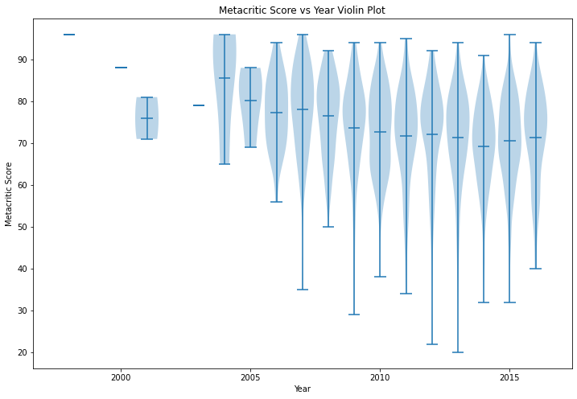

```python
# Generate violin plot
f = plt.figure(figsize=(12,8))
ax = f.add_subplot(xlabel='Year', ylabel='Metacritic Score', title='Metacritic Score vs Year Violin Plot',
                   xticks=[1995, 2000, 2005, 2010, 2015, 2020])
ax.violinplot(metacritic_by_year,years,widths=.9,showmeans=True)
;
```

This gives us a good idea of how the Metacritic scores are distributed for different years. We can see that in general, the average Metacritic score appears to be decreasing over time. This could mean more lower quality games are being released over time, or maybe that game reviewers' standards have gone up. It could also potentially imply sampling bias, as it is definitely possible there is a lack of data for older games, as opposed to newer ones.

Since we care about how different factors impact the success of a game, we will now compute another correlation matrix. This time, we will do a Spearman correlation, as we will be using qualitative variables in addition to continuous variables. The variables to include in this matrix will be ones that we think might have an impact on the success of a game, in addition to the variables that we use to measure success. Therefore, we can see if there exists a correlation between the factor and successes.

```python
# Columns to consider
corr_cols = ['ReleaseYear', 'SupportsEnglish', 'SupportsFrench', 'SupportsSpanish', 'SupportsChinese',
             'SupportsJapanese', 'SupportsKorean', 'LangSupportCount', 'AchievementCount', 'ControllerSupport',
             'IsFree', 'CategorySinglePlayer', 'CategoryMultiplayer', 'CategoryCoop', 'CategoryInAppPurchase',
             'GenreIsRPG', 'GenreIsIndie', 'GenreIsAdventure', 'GenreIsStrategy', 'GenreIsSimulation',
             'GenreIsAction','GenreIsRacing', 'GenreIsCasual', 'GenreIsSports', 'Metacritic', 'StandardizedRec',
             'SteamSpyOwners']
corr_df = df[corr_cols].copy()
```

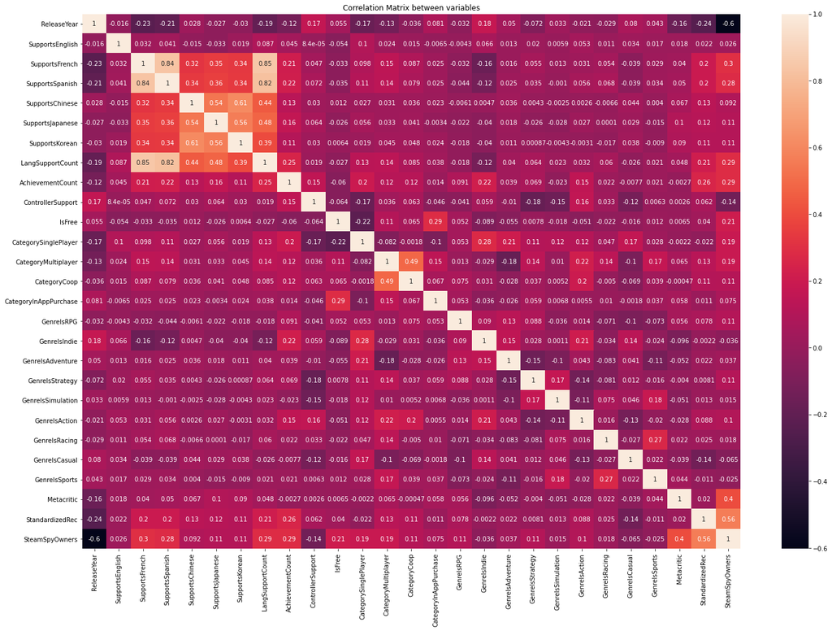

```python
# Create correlation matrix
corr_matrix = corr_df.corr(method='spearman')

plt.subplots(figsize = (24,16))
hm = sns.heatmap(corr_matrix, annot=True)
hm.set_title('Correlation Matrix between variables')
plt.show()
```

The chart seems massive and overwhelming, but we can mainly focus on the rows "Metacritic", "StandardizedRec", and "SteamSpyOwners", as they are our dependent variables for classifying a success.

A couple of interesting points (not relating to success of a game) are that the number of games that are classified as "indie" correlates with release year. In addition, it seems that indie games are generally single player, and classified as action games. Also, free games tend to be multiplayer games, and they tend to contain in app purchases (which makes sense from a monetization standpoint).

It is important to note that while there might exist correlations between two variables, that does not necessarily mean that one causes the other (i.e. correlation does not imply causation). In addition, there could be plenty of other factors that might cause one variable to correlate with another, which are not accounted for in this matrix. As a result, we cannot necessarily draw conclusions from this matrix alone. However, it allows us to get a sense of the data, and get a feel for what sort of things we might want to investigate further.

Now let's do one final visualization of our data. We want to see how different genres perform, so we can observe if there are game genres that usually do exceedingly well, or very poorly. We will create graphs with the "success statistic" on the y-axis, and the genres on the x-axis. The "success statistic" will be the genre's mean Metacritic score, their average Recommendations per player, and the average number of owners. Let's create 3 separate bar graphs for these 3 statistics.

```python
# List of all genres in dataset
genre_list = ['GenreIsIndie', 'GenreIsAction', 'GenreIsAdventure', 'GenreIsCasual', 'GenreIsStrategy', 'GenreIsRPG',
              'GenreIsSimulation', 'GenreIsEarlyAccess', 'GenreIsFreeToPlay', 'GenreIsSports', 'GenreIsRacing',
              'GenreIsMassivelyMultiplayer']

# Compute Metacritic score means, average recommendations per player, and average number of game owners for each genre
metacritic_means = []
rec_means = []
owners_means = []
for genre in genre_list:
    genre_df = df[df[genre] == 1]
    metacritic_means.append(genre_df.Metacritic.mean())
    rec_means.append(genre_df.StandardizedRec.mean())
    owners_means.append(genre_df.SteamSpyOwners.mean())
```

```
<BarContainer object of 12 artists>
```

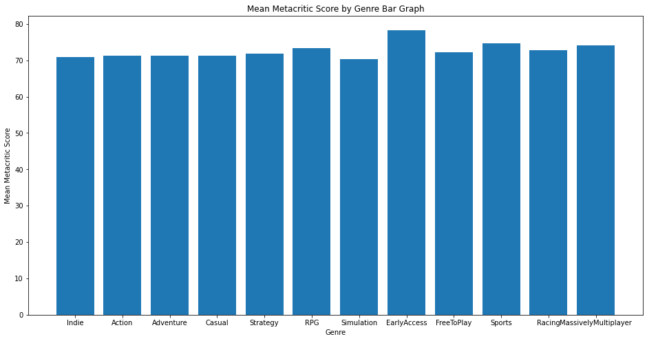

```python
# Remove the 'GenreIs' substring from each genre for readability in the final graph
genre_labels = [genre.replace('GenreIs', '') for genre in genre_list]

# Generate bar graph for Metacritic means by genre
f = plt.figure(figsize=(16,8))
ax = f.add_subplot(title='Mean Metacritic Score by Genre Bar Graph', xlabel='Genre', ylabel='Mean Metacritic Score')
ax.bar(genre_labels,metacritic_means)
```

```
<BarContainer object of 12 artists>
```

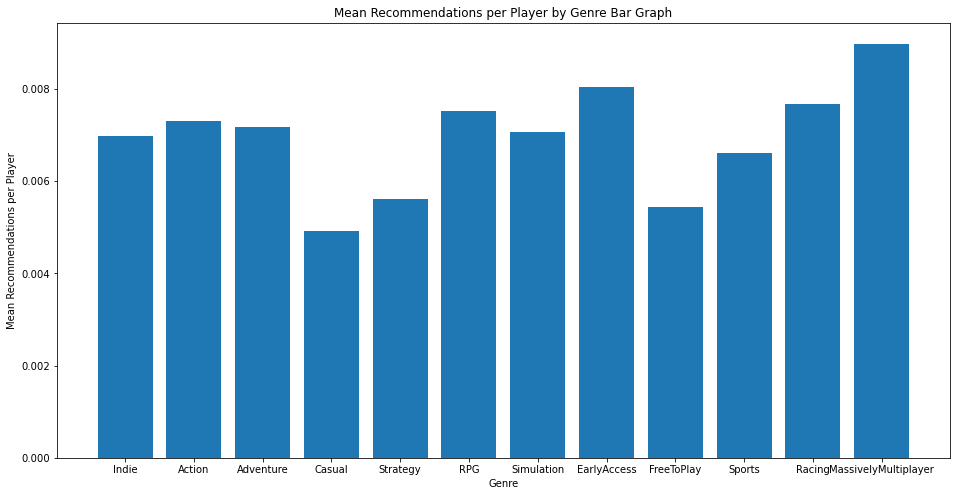

```python
# Generate bar graph for average recommendations per player by genre
f = plt.figure(figsize=(16,8))
ax = f.add_subplot(title='Mean Recommendations per Player by Genre Bar Graph', xlabel='Genre',
                   ylabel='Mean Recommendations per Player')
ax.bar(genre_labels,rec_means)
```

```
<BarContainer object of 12 artists>
```

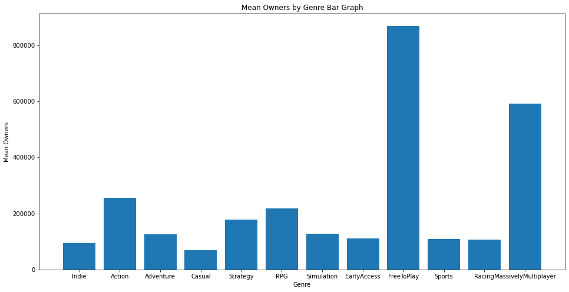

```python
# Generate bar graph for average owners by genre
f = plt.figure(figsize=(16,8))
ax = f.add_subplot(title='Mean Owners by Genre Bar Graph', xlabel='Genre', ylabel='Mean Owners')
ax.bar(genre_labels,owners_means)
```

There are some things to consider from these charts. Clearly, free to play games and MMO (Massively Multiplayer Online) games have the most owners out of any of the genres. This makes sense, since they are completely free, so there is no loss from getting the game, as opposed to a paid game. However, it seems that while free to play games are owned by many people, they are not very likely to be recommended, indicated by their relatively low recommendations per player number. On the other hand, MMOs have a lot of owners, and also a high recommendation per player number. Metacritic scores seem to be fairly equal across all genres, though there is an interesting increase for Early Access games. A possible cause for this could be the smaller sample size, as there are likely less EarlyAccess games than the other genres.

# Hypothesis Testing

This is the process in which we come up with statement that we want to verify. We need to come up with the null hypothesis, and the alternative hypothesis. The null hypothesis is the statement you want to reject, while the alternative hypothesis is the statement that you want to accept. Hypothesis tests allow us to make statistically significant conclusions using our data.

First we will state out significance level for our hypothesis tests in this project. We will use the following significance level:

$\alpha = 0.05$

Where alpha denotes the significance level. The significance level denotes the probability of making a Type 1 error, which is when you reject the null hypothesis when, in reality, it is actually true. Naturally, we would like to minimize such an error. However, if you choose a significance level that is too small, you might not be able to draw meaningful conclusions. As a result, a significance level of 0.05 strikes a balance between these two extremes.

We will perform a hypothesis test on every single pair of variables on our previous correlation matrix. In all of these instances, the null hypothesis will be that the two variables are NOT correlated. The alternative hypothesis is that the two variables are correlated. We will compute the p-values for all of the correlation coefficients that we found. Teh significance of the p-value is that it represents the probability that any observed correlation is due to chance. As a result, if the p-value is small (defined by being smaller than our significance level), we can reject the null hypothesis. In other words, if the p-value < 0.05, then it is likely there is a correlation between the two variables.

To perform such a hypothesis test on every pair of variables, we will compute a correlation matrix as before, but this time the values will be the p-values, instead of the correlation coefficient.

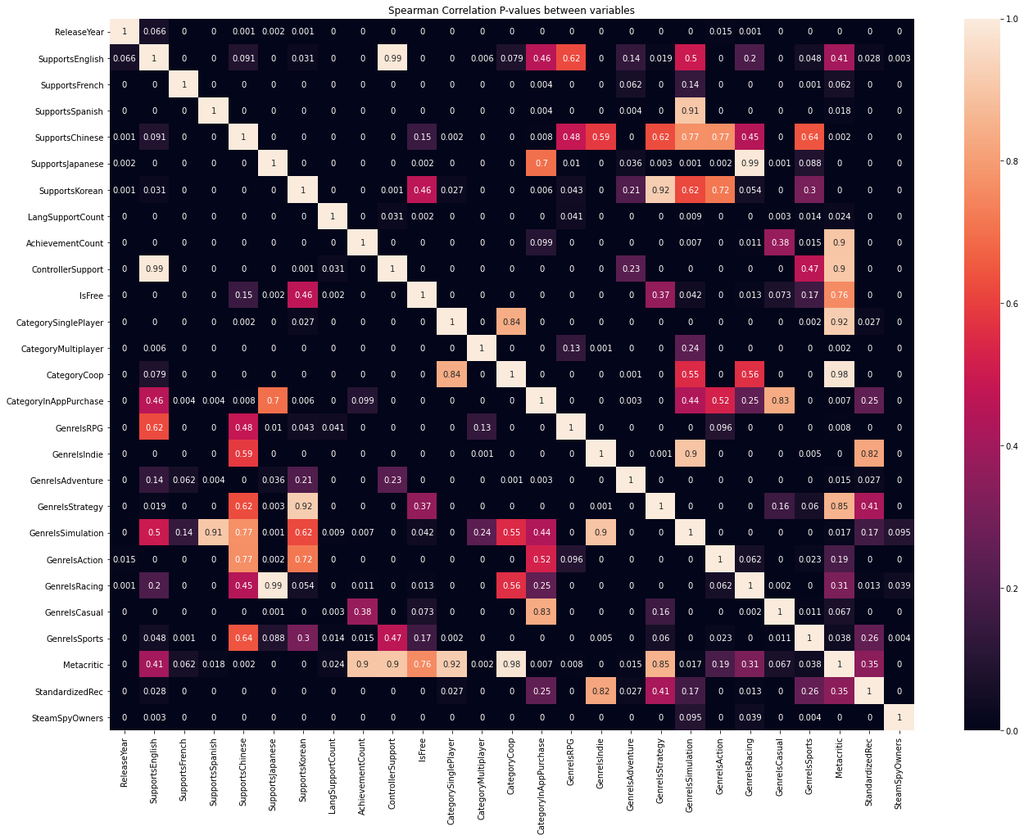

```python
# Create function that calculates p-value for the Spearman correlation coefficient. To be passed into corr function.
def spearmanr_pval(x,y):
    return round(spearmanr(x,y)[1], 3)

# Drop NaN values
df_nonan = df.dropna()

# Calculate correlation matrix, for p-values
corr_matrix = corr_df.corr(method=spearmanr_pval)

plt.subplots(figsize = (22,16))
hm = sns.heatmap(corr_matrix, annot=True)
hm.set_title('Spearman Correlation P-values between variables')
plt.show()
```

The darker squares represent a combination of variables that are more likely to be actually correlated, while the brighter colors mean the variables are more likely to be correlated only by chance. We can use this alongside our previously created correlation matrix to get a sense of which independent variables might be good predictors of our dependent variables. If the pair has a large correlation coefficient and a small p-value, it is likely that the independent variable in the pair is a good predictor of the dependent variable, as they are significantly correlated.

Now that we are armed with this information, let us try to make some claims regarding what independent variables are good predictors of our dependent variables (Metacritic, StandardizedRec, SteamSpyOwners).

We will fit a linear regression model for our dependent variable "Metacritic." Our dependent variables will be based on our previous correlation matrices. Independent variables with small p-values will be included in our model.

```python
# Fitting a linear model for the Metacritic dependent variable
df_metacritic = corr_df.dropna().copy()
# Remove variables with high p-values
X = df_metacritic.drop(['SupportsEnglish', 'AchievementCount', 'ControllerSupport', 'IsFree', 'CategorySinglePlayer',
                        'CategoryCoop', 'GenreIsStrategy', 'GenreIsAction', 'GenreIsRacing', 'GenreIsCasual',
                        'Metacritic', 'SteamSpyOwners', 'StandardizedRec'], axis=1)
y = df_metacritic['Metacritic']

X = sm.add_constant(X)
reg = sm.OLS(y, X).fit()
reg.summary()
```

OLS Regression Results

| Dep. Variable: | Metacritic | R-squared: | 0.062 |
| --- | --- | --- | --- |
| Model: | OLS | Adj. R-squared: | 0.056 |
| Method: | Least Squares | F-statistic: | 10.07 |
| Date: | Mon, 17 May 2021 | Prob (F-statistic): | 2.90e-22 |
| Time: | 17:29:36 | Log-Likelihood: | -8174.3 |
| No. Observations: | 2151 | AIC: | 1.638e+04 |
| Df Residuals: | 2136 | BIC: | 1.646e+04 |
| Df Model: | 14 |  |  |
| Covariance Type: | nonrobust |  |  |

|  | coef | std err | t | P>\|t\| | [0.025 | 0.975] |
| --- | --- | --- | --- | --- | --- | --- |
| const | 1694.8451 | 194.203 | 8.727 | 0.000 | 1313.999 | 2075.691 |
| ReleaseYear | -0.8072 | 0.097 | -8.357 | 0.000 | -0.997 | -0.618 |
| SupportsFrench | -0.8776 | 0.935 | -0.939 | 0.348 | -2.711 | 0.956 |
| SupportsSpanish | 0.0710 | 0.945 | 0.075 | 0.940 | -1.782 | 1.924 |
| SupportsChinese | 0.3537 | 1.146 | 0.309 | 0.758 | -1.894 | 2.602 |
| SupportsJapanese | 2.6555 | 0.821 | 3.233 | 0.001 | 1.045 | 4.266 |
| SupportsKorean | 1.0646 | 1.218 | 0.874 | 0.382 | -1.324 | 3.453 |
| LangSupportCount | 0.1829 | 0.126 | 1.452 | 0.147 | -0.064 | 0.430 |
| CategoryMultiplayer | 0.3358 | 0.514 | 0.653 | 0.514 | -0.673 | 1.345 |
| CategoryInAppPurchase | 6.0438 | 2.887 | 2.094 | 0.036 | 0.383 | 11.705 |
| GenreIsRPG | 2.2346 | 0.616 | 3.627 | 0.000 | 1.026 | 3.443 |
| GenreIsIndie | -0.0132 | 0.536 | -0.025 | 0.980 | -1.065 | 1.039 |
| GenreIsAdventure | 0.1145 | 0.546 | 0.210 | 0.834 | -0.957 | 1.185 |
| GenreIsSimulation | -1.1235 | 0.764 | -1.471 | 0.141 | -2.621 | 0.374 |
| GenreIsSports | 4.2578 | 1.461 | 2.914 | 0.004 | 1.392 | 7.124 |

| Omnibus: | 240.513 | Durbin-Watson: | 1.886 |
| --- | --- | --- | --- |
| Prob(Omnibus): | 0.000 | Jarque-Bera (JB): | 353.318 |
| Skew: | -0.828 | Prob(JB): | 1.90e-77 |
| Kurtosis: | 4.096 | Cond. No. | 1.67e+06 |

Notes:  
[1] Standard Errors assume that the covariance matrix of the errors is correctly specified.  
[2] The condition number is large, 1.67e+06. This might indicate that there are  
strong multicollinearity or other numerical problems.

Through this, we have obtained a linear model for predicting Metacritic scores based on various other independent factors. However, we must verify whether or not our coefficients for our variables are significantly different from zero. We do this through hypothesis testing.

We set our null hypothesis to be that our coefficient is not significantly different from zero. Our alternative hypothesis is that our coefficient is significantly different from zero. Then, we take a look at the p-values for each coefficient. If the p-value is less than our significance level (0.05), then we reject the null hypothesis. In other words, if the p-value < 0.05, then the coefficient is significantly different from zero, so the variable should belong in our model. Otherwise, the coefficient is not significantly different from zero, so we should likely exclude it from our model.

From the summary printed above, the p-values are listed in the "P>|t|" column. We can see that the variables with p-values that are less than 0.05 include the ReleaseYear, SupportsJapanese, CategoryInAppPurchase, GenreIsRPG, and GenreIsSports. The other variables have p-values greater than 0.05, so they have coefficients that are not significantly different from zero.

To get a sense of how our regression fits our data, let's create a violin plot of the residuals. A residual is simply the difference between the actual value in the data, and the value that was predicted by the linear regression (actual - prediction).

In general, if our residuals plot looks "spread out," then our regression can usually be considered a good fit for the data. In particular, we want our violins to look symmetrical about its mean, with each violin having a mean at approximately 0. In addition, we do not want to see any significant correlations in the residuals plot. If we did, it might indicate that a linear regression is not the best method of predicting the data.

```python
# Create new column for predictions
df_metacritic['Prediction'] = reg.predict(X)
# Create new column for the residuals
df_metacritic['Residual'] = df_metacritic['Metacritic'] - df_metacritic['Prediction']

yrs = df_metacritic.ReleaseYear.unique()
residuals_per_year = [(df_metacritic[df_metacritic['ReleaseYear']==year])['Residual'] for year in yrs]
```

```
''
```

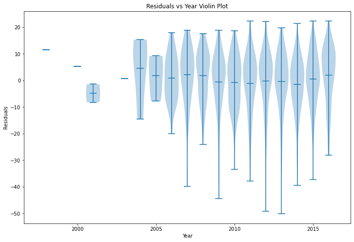

```python
# Create violin plot of residuals
f = plt.figure(figsize=(12,8))
ax = f.add_subplot(xlabel='Year', ylabel='Residuals', title='Residuals vs Year Violin Plot',
                   xticks=[1995, 2000, 2005, 2010, 2015, 2020])
ax.violinplot(residuals_per_year,yrs,widths=.9,showmeans=True)
;
```

Based on the residuals plot, this regression does not look to be the best. While the violins have symmetrical distributions across the mean, there seems to be some points with almost -50 residual values, while on the positive side, it only goes up to a little past 20. As a result, it does not look to be completely evenly scattered. One likely possibility is that our data for games before the year 2005 is fairly limited. We can see that before 2005, the violin plots look rather strange. This is because those years have such few observations, that there is not enough data to construct a whole violin, like in the later years. It could prove useful to remove those observations, and focus solely on 2005 and beyond.

Another likely cause of these residuals is the extremely low Metacritic score outliers that we can see in our previous violin plot in the EDA section. As stated earlier, technological innovations has made it easy for anyone to make games. As a result, it is definitely possible that these low Metacritic score games are those that are made by novices, with relatively poor quality. This is a clear shortcoming of this project, as we are only considering universal, objective factors, such as game genre. Subjective factors like game quality are extremely difficult to quantify, and therefore are undetectable by our model.

We will try fitting another model for our other dependent variable, "SteamSpyOwners," (i.e. the number of people who are estimated to own the game). We will go through the same process as we just did for Metacritic score, except this time, we will only perform this operation on games with a ReleaseYear after 2005. Hopefully, eliminating those outliers will help our model fit the data better.

```python
# Fitting a linear model for the Metacritic dependent variable
df_owners = corr_df.dropna()
df_owners = df_owners[df_owners.ReleaseYear > 2005].copy()
# Remove variables with high p-values
X = df_owners.drop(['Metacritic', 'SteamSpyOwners', 'StandardizedRec'], axis=1)
y = df_owners['SteamSpyOwners']

X = sm.add_constant(X)
reg = sm.OLS(y, X).fit()
reg.summary()
```

OLS Regression Results

| Dep. Variable: | SteamSpyOwners | R-squared: | 0.280 |
| --- | --- | --- | --- |
| Model: | OLS | Adj. R-squared: | 0.272 |
| Method: | Least Squares | F-statistic: | 34.25 |
| Date: | Mon, 17 May 2021 | Prob (F-statistic): | 7.04e-132 |
| Time: | 17:29:37 | Log-Likelihood: | -34119. |
| No. Observations: | 2138 | AIC: | 6.829e+04 |
| Df Residuals: | 2113 | BIC: | 6.843e+04 |
| Df Model: | 24 |  |  |
| Covariance Type: | nonrobust |  |  |

|  | coef | std err | t | P>\|t\| | [0.025 | 0.975] |
| --- | --- | --- | --- | --- | --- | --- |
| const | 2.62e+08 | 4.07e+07 | 6.437 | 0.000 | 1.82e+08 | 3.42e+08 |
| ReleaseYear | -1.297e+05 | 2.03e+04 | -6.404 | 0.000 | -1.69e+05 | -9e+04 |
| SupportsEnglish | 3.767e+05 | 1.04e+06 | 0.361 | 0.718 | -1.67e+06 | 2.42e+06 |
| SupportsFrench | -7.752e+05 | 1.81e+05 | -4.281 | 0.000 | -1.13e+06 | -4.2e+05 |
| SupportsSpanish | -3.301e+05 | 1.85e+05 | -1.781 | 0.075 | -6.94e+05 | 3.35e+04 |
| SupportsChinese | -3.823e+05 | 2.21e+05 | -1.731 | 0.084 | -8.15e+05 | 5.09e+04 |
| SupportsJapanese | -1.037e+05 | 1.59e+05 | -0.650 | 0.515 | -4.16e+05 | 2.09e+05 |
| SupportsKorean | 4.838e+05 | 2.36e+05 | 2.051 | 0.040 | 2.12e+04 | 9.46e+05 |
| LangSupportCount | 2.436e+05 | 2.43e+04 | 10.025 | 0.000 | 1.96e+05 | 2.91e+05 |
| AchievementCount | 410.2006 | 901.603 | 0.455 | 0.649 | -1357.921 | 2178.322 |
| ControllerSupport | 2.227e+05 | 1.18e+05 | 1.896 | 0.058 | -7701.723 | 4.53e+05 |
| IsFree | 1.228e+06 | 2.68e+05 | 4.576 | 0.000 | 7.01e+05 | 1.75e+06 |
| CategorySinglePlayer | -1.491e+06 | 2.65e+05 | -5.628 | 0.000 | -2.01e+06 | -9.72e+05 |
| CategoryMultiplayer | -2.602e+05 | 1.13e+05 | -2.297 | 0.022 | -4.82e+05 | -3.81e+04 |
| CategoryCoop | 4.37e+05 | 1.43e+05 | 3.052 | 0.002 | 1.56e+05 | 7.18e+05 |
| CategoryInAppPurchase | 9.083e+06 | 5.81e+05 | 15.636 | 0.000 | 7.94e+06 | 1.02e+07 |
| GenreIsRPG | -1.216e+04 | 1.21e+05 | -0.100 | 0.920 | -2.5e+05 | 2.26e+05 |
| GenreIsIndie | -1.624e+05 | 1.05e+05 | -1.540 | 0.124 | -3.69e+05 | 4.44e+04 |
| GenreIsAdventure | -1.333e+05 | 1.1e+05 | -1.214 | 0.225 | -3.49e+05 | 8.2e+04 |
| GenreIsStrategy | 1.202e+05 | 1.21e+05 | 0.990 | 0.322 | -1.18e+05 | 3.58e+05 |
| GenreIsSimulation | 5680.3441 | 1.51e+05 | 0.038 | 0.970 | -2.9e+05 | 3.01e+05 |
| GenreIsAction | 3.113e+05 | 1.04e+05 | 2.986 | 0.003 | 1.07e+05 | 5.16e+05 |
| GenreIsRacing | 3.603e+04 | 2.52e+05 | 0.143 | 0.886 | -4.57e+05 | 5.29e+05 |
| GenreIsCasual | -1.922e+05 | 1.58e+05 | -1.214 | 0.225 | -5.03e+05 | 1.18e+05 |
| GenreIsSports | -4.689e+05 | 3.01e+05 | -1.560 | 0.119 | -1.06e+06 | 1.21e+05 |

| Omnibus: | 4908.347 | Durbin-Watson: | 1.720 |
| --- | --- | --- | --- |
| Prob(Omnibus): | 0.000 | Jarque-Bera (JB): | 50593695.054 |
| Skew: | 21.246 | Prob(JB): | 0.00 |
| Kurtosis: | 755.417 | Cond. No. | 1.83e+06 |

Notes:  
[1] Standard Errors assume that the covariance matrix of the errors is correctly specified.  
[2] The condition number is large, 1.83e+06. This might indicate that there are  
strong multicollinearity or other numerical problems.

```python
# Create new column for predictions
df_owners['Prediction'] = reg.predict(X)
# Create new column for the residuals
df_owners['Residual'] = df_owners['SteamSpyOwners'] - df_owners['Prediction']

yrs = df_owners.ReleaseYear.unique()
residuals_per_year = [(df_owners[df_owners['ReleaseYear']==year])['Residual'] for year in yrs]
```

```
''
```

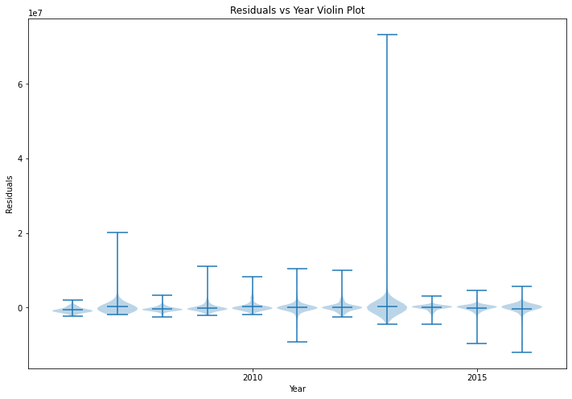

```python
# Create violin plot of residuals
f = plt.figure(figsize=(12,8))
ax = f.add_subplot(xlabel='Year', ylabel='Residuals', title='Residuals vs Year Violin Plot',
                   xticks=[1995, 2000, 2005, 2010, 2015, 2020])
ax.violinplot(residuals_per_year,yrs,widths=.9,showmeans=True)
;
```

We appear to run into a different problem this time around. There is a very clear, very extreme outlier. This is almost definitely due to a hyper popular game that is completely skewing the data. In other words, a game that is so popular, which such a large playerbase, that it greatly exceeds that of any other game on the platform. These are probably games that we would want to ignore in our analysis, as they are not necessarily representative of a typical game's success. If we wanted to fit a better model, we would have to decide some criteria or threshold of owners that classifies a game as "hyper-popular," and remove those games.

# Conclusion

In this project, we first tidied up our dataset. We made sure all of the data conformed to a set of rules that we defined, that would make it easy to work with. Then, we visualized the dataset through various graphs and plots. Through this, we were able to see how the data was distributed, and got a good overview of how the data might look. Next, we explored the dataset by searching for factors that might correlate with a successful game. Finally, we tried fitting linear models on the dataset, to get a model that could predict a game's success through various factors regarding the game, like the genre it is, or the year it was released.

As one can imagine, it is incredibly difficult to predict what sort of factors would result in a successful game. First of all, our dataset is far from perfect. We do not know the exact numbers of owners for each game (as Steam does not provide such data), so we must rely on SteamSpy estimates. In addition, not all games on Steam are classified correctly by genre, making it difficult to know exactly what genre each game actually is. Another reason is that games are incredibly subjective. There are so many factors that are impossible to quantify, such as game quality, polish, and feel. It would be incredibly difficult to somehow come up with a model that takes all of these things into account, if it is even possible. In terms of things that we can quantify, this project has some shortcomings as well. It might be important to consider the budget on which games are being developed. For example, if you are a small studio making games, you might want to compare yourself against other games with a similar budget, rather than with massive companies with millions of dollars.

There is a ton of data in this dataset, so there is a lot of different analyses that could be made. In addition, I wasn't able to use some of the data that I tidied, as there are so many factors to consider. I definitely encourage you to take a look at it yourself, and see what sort of insights you might be able to derive, if you are interested in the topic.

I hope this project helped you get a good introduction to the data science pipeline, and provided you with some insights into what sort of factors MIGHT go into making a "successful" game. At the very least, I hope you are able to walk away knowing a little bit more about game development, the statistics of Steam games, and maybe a little bit of inspiration to look deeper into these things yourself!

# Related Links

- [Kaggle](https://www.kaggle.com/) is a great resource for finding datasets
- The [Pandas Documentation](https://pandas.pydata.org/docs/) is very useful for learning about DataFrames and their operations
- [How to Tidy Data?](https://towardsdatascience.com/what-is-tidy-data-d58bb9ad2458)
- [Step-by-Step Process of EDA](https://towardsdatascience.com/an-extensive-guide-to-exploratory-data-analysis-ddd99a03199e)
- [Creating a Linear Regression Model in Python](https://realpython.com/linear-regression-in-python/)